# Reproducible Summary Tables with the gtsummary Package

The *gtsummary* package provides an elegant and flexible way to create publication-ready summary tables in R. A critical part of the work of statisticians, data scientists, and analysts is summarizing data sets and regression models in R and publishing or sharing polished summary tables. The *gtsummary* package was created to streamline these everyday analysis tasks by allowing users to easily create reproducible summaries of data sets, regression models, survey data, and survival data with a simple interface and very little code. The package follows a tidy framework, making it easy to integrate with standard data workflows, and offers many table customization features through function arguments, helper functions, and custom themes.

Daniel D. Sjoberg (Memorial Sloan Kettering Cancer Center) , Karissa Whiting (Memorial Sloan Kettering Cancer Center) , Michael Curry (Memorial Sloan Kettering Cancer Center) , Jessica A. Lavery (Memorial Sloan Kettering Cancer Center) , Joseph Larmarange (Centre Population & Développement, IRD, Université de Paris, Inserm)  
2021-06-22

## 1 Introduction

Table summaries are a fundamental tool in an analyst’s toolbox that help us understand and communicate patterns in our data. The ability to easily create and export polished and reproducible tables is essential. The [*gtsummary*](https://CRAN.R-project.org/package=gtsummary) (Sjoberg et al. 2020) package provides an elegant and flexible framework to create publication-ready analytical and summary tables in R. This package works to close the gap between a reproducible RMarkdown report and the final report. Specifically, *gtsummary* allows the user to fully customize and format summary tables with code, eliminating the need to modify any tables by hand after the table has been exported. Removing the need to modify tables after the table has been created eliminates an error-prone step in our workflow and increases the reproducibility of our analyses and reports.

Using *gtsummary*, analysts can easily summarize data frames, present and compare descriptive statistics between groups, summarize regression models, and report statistics inline in RMarkdown reports. After identifying these basic structures of most tables presented in the medical literature (and other fields), we wrote *gtsummary* to ease the creation of fully-formatted, ready-to-publish tables.

Additionally, *gtsummary* leverages other analysis and tidying R packages to create a complete analysis and reporting framework. For example, we take advantage of the existing [*broom*](https://CRAN.R-project.org/package=broom) (Robinson et al. 2020) tidiers to prepare regression results for `tbl_regression()` and use [*gt*](https://CRAN.R-project.org/package=gt) (Iannone et al. 2020) to print *gtsummary* tables to various output formats (e.g., HTML, PDF, Word, or RTF). Furthermore, *gtsummary* functions are designed to work within a "tidy" framework, utilizing the [*magrittr*](https://CRAN.R-project.org/package=magrittr) (Bache and Wickham 2020) pipe operator and [*tidyselect*](https://CRAN.R-project.org/package=tidyselect) (Henry and Wickham 2020) functions used throughout the [*tidyverse*](https://CRAN.R-project.org/package=tidyverse) (Wickham et al. 2019).

While other R packages are available to present data and regression model summary tables, such as [*skimr*](https://CRAN.R-project.org/package=skimr), [*stargazer*](https://CRAN.R-project.org/package=stargazer), [*finalfit*](https://CRAN.R-project.org/package=finalfit), and [*tableone*](https://CRAN.R-project.org/package=tableone), *gtsummary* is unique in that it is a one-stop-shop for most types of statistical tables and offers diverse features to customize the content of tables to a high degree. The default [*gtsummary*](https://CRAN.R-project.org/package=gtsummary) table is suitable to be published in a scientific journal with little or no additional formatting. For example, [*gtsummary*](https://CRAN.R-project.org/package=gtsummary) has specific internal algorithms to identify variable data types, so there is no need for users to specify whether a variable should be displayed with categorical or continuous summaries, which yields summary tables with minimal code.

Along with descriptive summaries, *gtsummary* summarizes statistical models, survey data, survival data and builds cross-tabulations. After data are summarized in a table, *gtsummary* allows users to combine tables, either side-by-side (with `tbl_merge()`) , or on top of each other (with `tbl_stack()`). The table merging and stacking abilities allows analysts to easily synthesize and compare output from several tables and share information in a compact format. All tables in this manuscript were created using *gtsummary* v1.4.1.

## 2 Data Summaries

To showcase *gtsummary* functions, we will use a simulated clinical trial data set containing baseline characteristics of 200 patients who received Drug A or Drug B, as well as the outcomes of tumor response and death. Each variable in the data frame has been assigned an attribute label with the *labelled* package (Larmarange 2020), e.g., `trial %>% set_variable_labels(age = "Age")`, that will be shown in the summary tables. These labels are displayed in the *gtsummary* tables by default, and had labels not been assigned, the variable name would have been shown.

Table 1: Example data frame, `trial`

| colname | label | class | values |
| --- | --- | --- | --- |
| `trt` | Chemotherapy Treatment | character | `Drug A`, `Drug B` |
| `age` | Age | numeric | `6`, `9`, `10`, `17`, ... |
| `marker` | Marker Level (ng/mL) | numeric | `0.003`, `0.005`, `0.013`, `0.015`, ... |
| `stage` | T Stage | factor | `T1`, `T2`, `T3`, `T4` |
| `grade` | Grade | factor | `I`, `II`, `III` |
| `response` | Tumor Response | integer | `0`, `1` |
| `death` | Patient Died | integer | `0`, `1` |
| `ttdeath` | Months to Death/Censor | numeric | `3.53`, `5.33`, `6.32`, `7.27`, ... |

### 2.1 `tbl_summary()`

The default output from `tbl_summary()` is meant to be publication-ready. The `tbl_summary()` function can take, at minimum, a data frame as the only input, and returns descriptive statistics for each column in the data frame. This is often the first table of clinical manuscripts and describes the characteristics of the study cohort. A simple example is shown below. Notably, by specifying the `by=` argument, you can stratify the summary table. In the example below, we have split the table by the treatment a patient received.

```r
trial %>%
  select(age, grade, response, trt) %>%
  tbl_summary(by = trt)
```

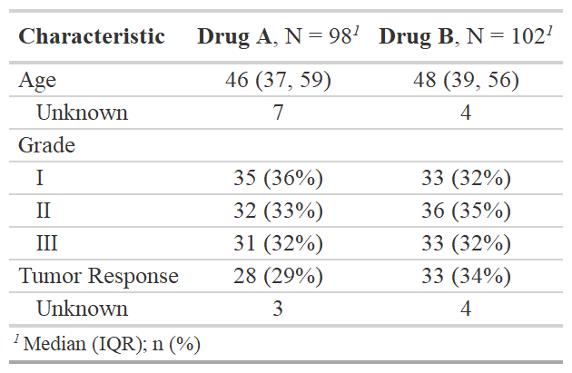

The function is highly customizable, and it is initiated with sensible default settings. Specifically, `tbl_summary()` detects variable types of input data and calculates descriptive statistics accordingly. For example, variables coded as `0/1`, `TRUE/FALSE`, and `Yes/No` are presented dichotomously. Additionally, `NA` values are recognized as missing and listed as unknown, and if a data set is labeled, the label attributes are utilized.

Default settings may be customized using the `tbl_summary()` function arguments.

Table 2: `tbl_summary()` function arguments

| Argument | Description |
| --- | --- |
| `label=` | specify the variable labels printed in table |
| `type=` | specify the variable type (e.g., continuous, categorical, etc.) |
| `statistic=` | change the summary statistics presented |
| `digits=` | number of digits the summary statistics will be rounded to |
| `missing=` | whether to display a row with the number of missing observations |
| `missing_text=` | text label for the missing number row |
| `sort=` | change the sorting of categorical levels by frequency |
| `percent=` | print column, row, or cell percentages |
| `include=` | list of variables to include in summary table |

For continuous variables, tables display one row of statistics per variable by default. This can be customized, and in the example below, the age variable is cast to `"continuous2"` type, meaning the continuous summary statistics will appear on two or more rows in the table. This allows the number of non-missing observations and the mean to be displayed on separate lines.

In the example below, the `"age"` variable’s label is updated to `"Patient Age"`. Default summary statistics for both continuous and categorical variables are updated using the `statistic=` argument. *gtsummary* uses [*glue*](https://CRAN.R-project.org/package=glue) (Hester 2020) syntax to construct the statistics displayed in the table. Function names appearing in curly brackets will be replaced by the evaluated value. The `digits=` argument is used to increase the number of decimal places to which the statistics are rounded, and the missing row is omitted with `missing = "no"`.

```r
trial %>%
  select(age, grade, response, trt) %>%
  tbl_summary(
    by = trt,
    type = age ~ "continuous2",
    label = age ~ "Patient Age",
    statistic = list(age ~ c("{N_nonmiss}", "{mean} ({sd})"),
                     c(grade, response) ~ "{n} / {N} ({p}%)"),
    digits = c(grade, response) ~ c(0, 0, 1),
    missing = "no"
  )
```

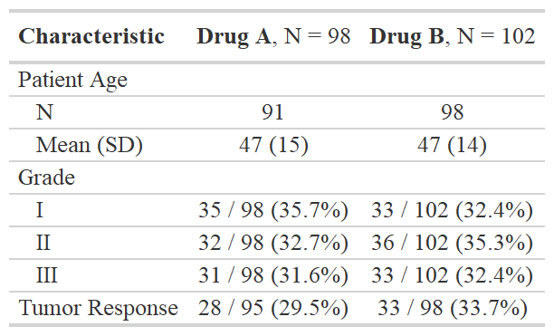

**A note about notation:** Throughout the *gtsummary* package, you will find function arguments that accept a list of formulas (or a single formula) as the input. In the example above, the label for the age variable was updated using `label = age`$\sim$`"Patient Age"`—equivalently, `label = list(age`$\sim$`"Patient Age")`. To select groups of variables, utilize the select helpers from the *tidyselect* and *gtsummary* packages. The `all_continuous()` selector is a convenient way to select all continuous variables. In the example above, it could have been used to change the summary statistics for all continuous variables—`all_continuous()`$\sim$`c("{N_nonmiss}", "{mean} ({sd})")`. Similarly, users may utilize `all_categorical()` (from *gtsummary*) or any of the *tidyselect* helpers used throughout the *tidyverse* packages, such as `starts_with()`, `contains()`, etc.

In addition to summary statistics, the *gtsummary* package has several functions to add additional information or statistics to `tbl_summary()` tables.

Table 3: `tbl_summary()` functions to add information

| Function | Description |
| --- | --- |
| `add_p()` | add *p*-values to the output comparing values across groups |
| `add_overall()` | add a column with overall summary statistics |
| `add_n()` | add a column with N (or N missing) for each variable |
| `add_difference()` | add column for difference between two group, confidence interval, and *p*-value |
| `add_stat_label()` | add label for the summary statistics shown in each row |
| `add_stat()` | generic function to add a column with user-defined values |
| `add_q()` | add a column of *q*-values to control for multiple comparisons |

In the example below, descriptive statistics are shown by the treatment received and overall, as well as a *p*-value comparing the values between the treatments. Default statistical tests are chosen based on data type, and the statistical test performed can be customized in the `add_p()` function. *p*-value formatting can be adjusted using the `pvalue_fun=` argument, which accepts both a proper function, as well the formula shortcut notation used throughout the *tidyverse* packages.

```r
trial %>%
  select(age, grade, response, trt) %>%
  tbl_summary(by = trt) %>%
  add_overall() %>%
  add_p(test = all_continuous() ~ "t.test",
        pvalue_fun = ~style_pvalue(., digits = 2))
```

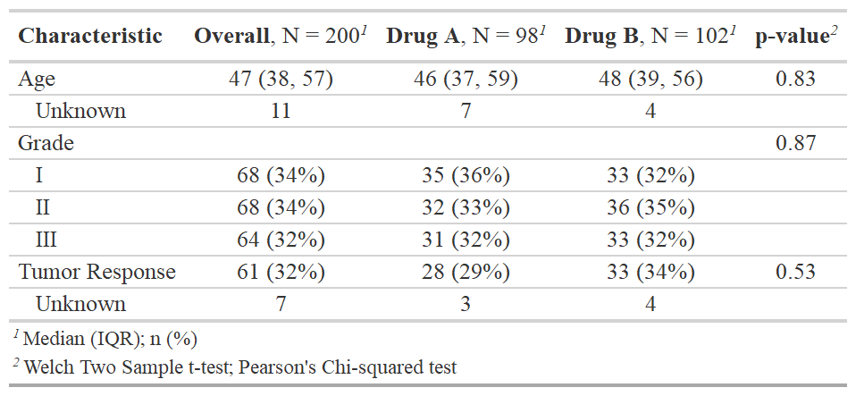

### 2.2 `tbl_svysummary()`

The `tbl_svysummary()` function is analogous to `tbl_summary()`, except a [*survey*](https://CRAN.R-project.org/package=survey) (Lumley 2020) object is supplied rather than a data frame. The summary statistics presented take into account the survey weights, as do any *p*-values presented.

```r
# convert trial data frame to survey object
svy_trial <- survey::svydesign(data = trial, ids = ~ 1, weights = ~ 1)

tbl_svysummary_1 <-
  svy_trial %>%
  tbl_svysummary(by = trt, include = c(trt, age, grade)) %>%
  add_p()
```

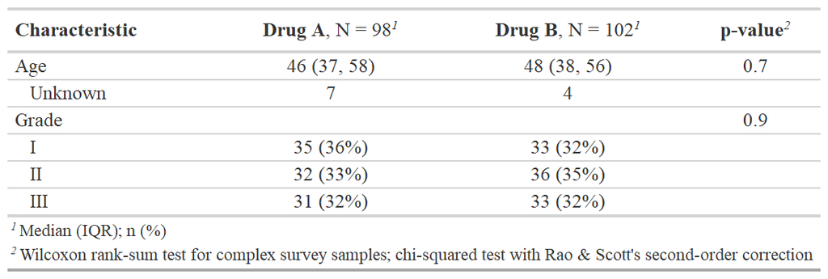

### 2.3 `tbl_cross()`

The `tbl_cross()` function is a wrapper for `tbl_summary()` and creates a simple, publication-ready cross tabulation.

```r
trial %>%
  tbl_cross(row = stage, col = trt, percent = "cell") %>%
  add_p(source_note = TRUE)
```

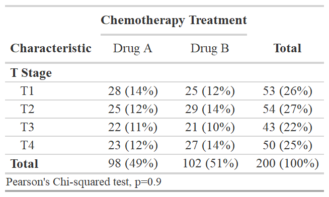

### 2.4 `tbl_survfit()`

The `tbl_survfit()` function parses and tabulates `survival::survfit()` objects presenting survival percentile estimates and survival probabilities at specified times.

```r
library(survival)

list(survfit(Surv(ttdeath, death) ~ trt, trial),
     survfit(Surv(ttdeath, death) ~ grade, trial)) %>%
  tbl_survfit(times = c(12, 24),
              label_header = "**{time} Month**") %>%
  add_p()
```

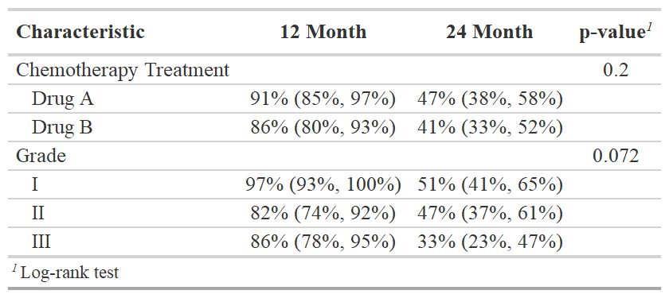

### 2.5 Customization

The *gtsummary* package includes functions specifically made to modify and format the summary tables. These functions work with any table constructed with *gtsummary*. The most common uses are changing the column headers and footnotes or modifying the look of tables through bolding and italicization.

Table 4: Functions to style and modify gtsummary tables

| Function | Description |
| --- | --- |
| `modify_header()` | update column headers |
| `modify_footnote()` | update column footnote |
| `modify_spanning_header()` | update spanning headers |
| `modify_caption()` | update table caption/title |
| `bold_labels()` | bold variable labels |
| `bold_levels()` | bold variable levels |
| `italicize_labels()` | italicize variable labels |
| `italicize_levels()` | italicize variable levels |
| `bold_p()` | bold significant *p*-values |

The *gtsummary* package utilizes the *gt* package to print the summary tables. The *gt* package exports approximately one hundred functions to customize and style tables. When you need to add additional details or styling not available within *gtsummary*, use the `as_gt()` function to convert the *gtsummary* object to *gt* and continue customization.

The example below is a common table reported in clinical trials and observational research where two treatments are compared. The treatment differences were added with the `add_difference()` function. The table includes customization using both *gtsummary* and *gt* functions. The *gtsummary* functions are utilized to bold the variable labels, update the column headers, and add a spanning header. Additional *gt* customization was utilized to add table captions and source notes.

```r
trial %>%
  select(marker, response, trt) %>%
  tbl_summary(by = trt,
              missing = "no",
              statistic = marker ~ "{mean} ({sd})") %>%
  add_difference() %>%
  add_n() %>%
  add_stat_label() %>%
  bold_labels() %>%
  modify_header(list(label ~ "**Variable**", all_stat_cols() ~ "**{level}**")) %>%
  modify_spanning_header(all_stat_cols() ~ "**Randomization Assignment**") %>%
  as_gt() %>%
  gt::tab_header(
    title = gt::md("**Table 1. Treatment Differences**"),
    subtitle = gt::md("_Highly Confidential_")
  ) %>%
  gt::tab_source_note("Data updated June 26, 2015")
```

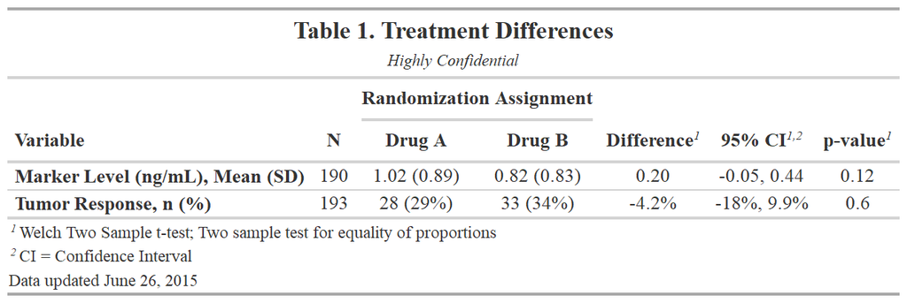

## 3 Model Summaries

Regression modeling is one of the most common tools of medical research. The *gtsummary* package has two functions to help analysts prepare tabular summaries of regression models: `tbl_regression()` and `tbl_uvregression()`.

### 3.1 `tbl_regression()`

The `tbl_regression()` function takes a regression model object in R and returns a formatted table of regression model results. Like `tbl_summary()`, `tbl_regression()` creates highly customizable analytic tables with sensible defaults. Common regression models, such as logistic regression and Cox proportional hazards regression, are automatically identified, and the tables headers are pre-filled with appropriate column headers (i.e., Odds Ratio and Hazard Ratio).

In the example below, the logistic regression model is summarized with `tbl_regression()`. Note that a reference row for grade has been added, and the variable labels have been carried through into the table. Using `exponentiate = TRUE`, we exponentiate the regression coefficients, yielding the odds ratios. The helper function `add_global_p()` was used to replace the *p*-values for each term with the global *p*-value for grade.

```r
glm(response ~ age + grade, trial, family = binomial) %>%
  tbl_regression(exponentiate = TRUE) %>%
  add_global_p()
```

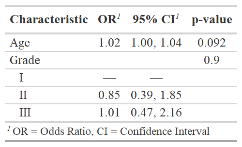

The `tbl_regression()` function leverages the huge effort behind the *broom*, [*parameters*](https://CRAN.R-project.org/package=parameters) (Lüdecke et al. 2020), and [*broom.helpers*](https://CRAN.R-project.org/package=broom.helpers) (Larmarange and Sjoberg 2021) packages to perform the initial formatting of the regression object. Because `tbl_regression()` utilizes these packages, there are many model types that are supported out of the box, such as `lm()`, `glm()`, `lme4::lmer()`, `lme4::glmer()`, `geepack::geeglm()`, `survival::coxph()`, `survival::survreg()`, `survival::clogit()`, `nnet::multinom()`, `rstanarm::stan_glm()`, models built with the *mice* package (van Buuren and Groothuis-Oudshoorn 2011), and many more. A custom tidier may be specified as well, which is helpful when you need to present non-standard modifications to your model results such as Wald confidence intervals or results with modified variance-covariance standard errors.

### 3.2 `tbl_uvregression()`

The `tbl_uvregression()` function is a wrapper for `tbl_regression()` that is useful when you need a series of univariate regression models. The user passes a data frame to `tbl_uvregression()`, indicates what the outcome is, what regression model to run, and the function will return a formatted table of stacked univariate regression models.

```r
trial %>%
  select(response, age, grade) %>%
  tbl_uvregression(
    y = response,
    method = glm,
    method.args = list(family = binomial),
    exponentiate = TRUE,
    pvalue_fun = ~style_pvalue(., digits = 2)
  ) %>%
  add_nevent() %>%
  add_global_p()
```

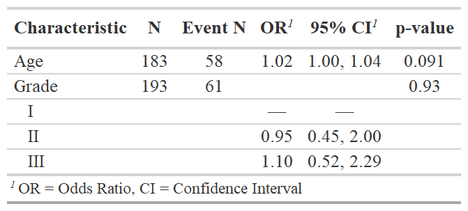

## 4 Inline Reporting

Reproducible reports are an important part of good analytic practices. We often need to report the results from a table in the text of an R markdown report. The `inline_text()` function reports statistics from *gtsummary* tables inline in an R markdown document.

Imagine you need to report the results for age from the univariate table above. Typically, the odds ratio, confidence interval, and *p*-value would be hard-coded into a report, which can lead to reproducibility issues if the data is updated and the hard-coded statistics are not amended. A simple call to the `inline_text()` function will dynamically add the model results to an RMarkdown report.

> The odds ratio for age was `r inline_text(uvreg, variable = age)`.

Here is how the line will appear in your report.

> The odds ratio for age was 1.02 (95% CI 1.00, 1.04; p=0.091).

The default pattern to display for a regression table is `"{estimate} ({conf.level*100}% CI {conf.low}, {conf.high}; {p.value})"` (again using glue syntax), and can be modified with the `inline_text(pattern=)` argument.

## 5 Merging and Stacking

The *gtsummary* tables shown above are often ready for publication as they are; however, it is common that more complex tables need to be constructed. This can be achieved by merging or stacking *gtsummary* tables using the `tbl_merge()` and `tbl_stack()` functions. For example, in cancer research we often report models predicting a tumor’s response to treatment and risk of death side-by-side in publications. This type of table is simple to construct using `tbl_merge()`. First, build a table for each regression model using `tbl_regression()`, then merge the two tables with `tbl_merge()`. Any number of *gtsummary* tables can be merged with this function.

```r
tbl1 <-
  glm(response ~ age + grade, trial, family = binomial) %>%
  tbl_regression(exponentiate = TRUE)

tbl2 <-
  coxph(Surv(ttdeath, death) ~ age + grade, trial) %>%
  tbl_regression(exponentiate = TRUE)

tbl_merge_1 <-
  tbl_merge(
    tbls = list(tbl1, tbl2),
    tab_spanner = c("**Tumor Response**", "**Time to Death**")
  )
```

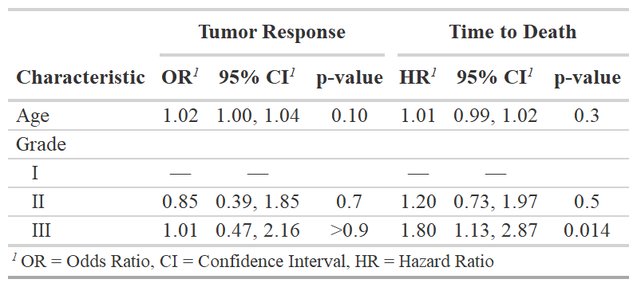

Similarly, any number of *gtsummary* tables may be stacked using the `tbl_stack()` function.

## 6 Themes

We love themes. The default styling (e.g., statistics displayed in `tbl_summary()`, how *p*-values are rounded, decimal separator, and more) follow the reporting guidelines from European Urology, The Journal of Urology, Urology, and the British Journal of Urology International (Assel et al. 2019). However, you will likely submit to another journal, or your personal preferences differ from the defaults. The *gtsummary* package is unique from other table building packages with the ability to set fine-grained customization defaults with themes. Themes were created to make these customizations easy to navigate and reuse across documents or projects. With themes, users can control default settings for existing functions (e.g., always present means instead of medians in `tbl_summary()`), as well as other changes that are not modifiable with function arguments. Several themes are available to follow various journals’ reporting guidelines, reduce cell padding and font size, and language themes to translate *gtsummary* tables to more than 14 languages.

For example, using the theme for *The Journal of the American Medical Association* (*JAMA*), large *p*-values are rounded to two decimal places, confidence intervals are shown as `"lb to ub"` instead of `"lb, ub"`, and the confidence interval is displayed in the same column as the model coefficients.

```r
theme_gtsummary_journal("jama")

glm(response ~ age + grade, trial, family = binomial) %>%
  tbl_regression(exponentiate = TRUE)
```

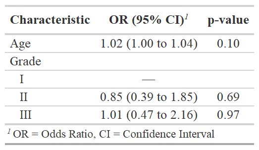

The language theme can be used to translate the table to another language and allows users to specify the decimal and big mark symbols. For example, `theme_gtsummary_language(language = "es", decimal.mark = ",", big.mark = ".")` will translate the output to Spanish and format numeric results as `1.000,00` instead of `1,000.00` (the default formatting).

A custom theme was used to construct the *gtsummary* tables shown in this manuscript to match the *R Journal* font and reduce the default cell padding. Themes are an evolving feature, and we welcome additions of new journals’ reporting guidelines or other themes useful to users. A full glossary of customizable theme elements is available in the package’s themes vignette (http://www.danieldsjoberg.com/gtsummary/articles/themes.html).

## 7 Print Engines

Tables printed with *gtsummary* can be seamlessly integrated into RMarkdown documents and knitted into various output types using a number of print engines. The package was written to be a companion to the *gt* package from RStudio and is optimized to leverage the advanced customization features of this print engine, but offers compatibility with a variety of popular printing methods, including `knitr::kable()` (Xie 2020), [*flextable*](https://CRAN.R-project.org/package=flextable) (Gohel 2020), [*huxtable*](https://CRAN.R-project.org/package=huxtable) (Hugh-Jones 2020), and [*kableExtra*](https://CRAN.R-project.org/package=kableExtra) (Zhu 2020). While *gt* is used as the default for most outputs, you can easily use your print engine of choice with the conversion helper functions provided in the package (e.g., `as_flex_table()`). It is possible to get results in HTML, PDF (via LaTeX), RTF, Microsoft Word, PowerPoint, Excel, and others, utilizing the various print engines. The package is designed to interact with these print engines behind the scenes to reduce the burden on users, and you generally only need to be aware of them if you want to add advanced customizations.

## 8 Summary

The functions in the *gtsummary* package were designed to reduce the burden of reporting and to work together to easily construct both simple and complex tables. It is our hope that the user-friendly syntax and publication-ready tables will aid analysts in preparing reproducible and high-quality findings.

### 8.1 Supplementary materials

Supplementary materials are available in addition to this article. It can be downloaded at RJ-2021-053.zip

### 8.2 CRAN packages used

gtsummary, broom, gt, magrittr, tidyselect, tidyverse, skimr, stargazer, finalfit, tableone, glue, survey, parameters, broom.helpers, flextable, huxtable, kableExtra

### 8.3 CRAN Task Views implied by cited packages

CausalInference, ChemPhys, Distributions, MixedModels, OfficialStatistics, ReproducibleResearch, Survival

M. Assel, D. Sjoberg, A. Elders, X. Wang, D. Huo, A. Botchway, K. Delfino, Y. Fan, Z. Zhao, T. Koyama, et al. Guidelines for reporting of statistics for clinical research in urology. *European urology*, 75(3): 358, 2019.

S. M. Bache and H. Wickham. *Magrittr: A forward-pipe operator for r.* 2020. URL https://CRAN.R-project.org/package=magrittr. R package version 2.0.1.

D. Gohel. *Flextable: Functions for tabular reporting.* 2020. URL https://CRAN.R-project.org/package=flextable. R package version 0.6.1.

L. Henry and H. Wickham. *Tidyselect: Select from a set of strings.* 2020. URL https://CRAN.R-project.org/package=tidyselect. R package version 1.1.0.

J. Hester. *Glue: Interpreted string literals.* 2020. URL https://CRAN.R-project.org/package=glue. R package version 1.4.2.

D. Hugh-Jones. *Huxtable: Easily create and style tables for LaTeX, HTML and other formats.* 2020. URL https://CRAN.R-project.org/package=huxtable. R package version 5.1.1.

R. Iannone, J. Cheng and B. Schloerke. *Gt: Easily create presentation-ready display tables.* 2020. https://gt.rstudio.com/, https://github.com/rstudio/gt.

J. Larmarange. *Labelled: Manipulating labelled data.* 2020. URL https://CRAN.R-project.org/package=labelled. R package version 2.7.0.

J. Larmarange and D. D. Sjoberg. *Broom.helpers: Helpers for model coefficients tibbles.* 2021. URL https://CRAN.R-project.org/package=broom.helpers. R package version 1.3.0.

D. Lüdecke, M. S. Ben-Shachar, I. Patil and D. Makowski. Extracting, computing and exploring the parameters of statistical models using R. *Journal of Open Source Software*, 5(53): 2445, 2020. DOI 10.21105/joss.02445.

T. Lumley. *Survey: Analysis of complex survey samples.* 2020. URL https://CRAN.R-project.org/package=survey. R package version 4.0.

D. Robinson, A. Hayes and S. Couch. *Broom: Convert statistical objects into tidy tibbles.* 2020. URL https://CRAN.R-project.org/package=broom. R package version 0.7.2.

D. D. Sjoberg, M. Curry, M. Hannum, K. Whiting and E. C. Zabor. *Gtsummary: Presentation-ready data summary and analytic result tables.* 2020. URL https://CRAN.R-project.org/package=gtsummary. R package version 1.3.6, https://github.com/ddsjoberg/gtsummary, http://www.danieldsjoberg.com/gtsummary/.

S. van Buuren and K. Groothuis-Oudshoorn. mice: Multivariate imputation by chained equations in r. *Journal of Statistical Software*, 45(3): 1–67, 2011. URL https://www.jstatsoft.org/v45/i03/.

H. Wickham, M. Averick, J. Bryan, W. Chang, L. D. McGowan, R. François, G. Grolemund, A. Hayes, L. Henry, J. Hester, et al. Welcome to the tidyverse. *Journal of Open Source Software*, 4(43): 1686, 2019. DOI 10.21105/joss.01686.

Y. Xie. *Knitr: A general-purpose package for dynamic report generation in r.* 2020. URL https://CRAN.R-project.org/package=knitr. R package version 1.30.

H. Zhu. *kableExtra: Construct complex table with ’kable’ and pipe syntax.* 2020. URL https://CRAN.R-project.org/package=kableExtra. R package version 1.3.1.